# Ramme for patientsikkerhed

31 jul 2018

## Program

1. Konceptualisering af patientsikkerhed
2. Anvendelse
3. Cases
   - Forslag fra sagkyndig
   - UTH
   - Data eksempler
4. Afrunding

## Overordnede rammer

- Vision:  
  Et sikkert og lærende sundhedsvæsen
- Mission:  
  Vi arbejder for, at det er trygt (sikkert) at være patient
- Opdrag :  
  Hvor er risikoen for patientsikkerhed størst

## Udfordringer?

1. Hvad forstår vi ved patientsikkerhed?
2. Hvad forstår vi ved risiko?
3. Hvordan identificeres temaer og områder?
4. Hvordan identificeres behandlingssteder?
5. Hvordan sikrer vi os at vores tiltag gavner?
6. Hvem skal der gås reaktivt tilsyn på?
7. Hvilke data skal vi bruge og hvordan?

## Centrale begreber

Sikkerhed:  
Fravær af skade

Patientsikkerhed:  
Fraværet af beskadigelse i rollen som patient

#### Skade er centralt

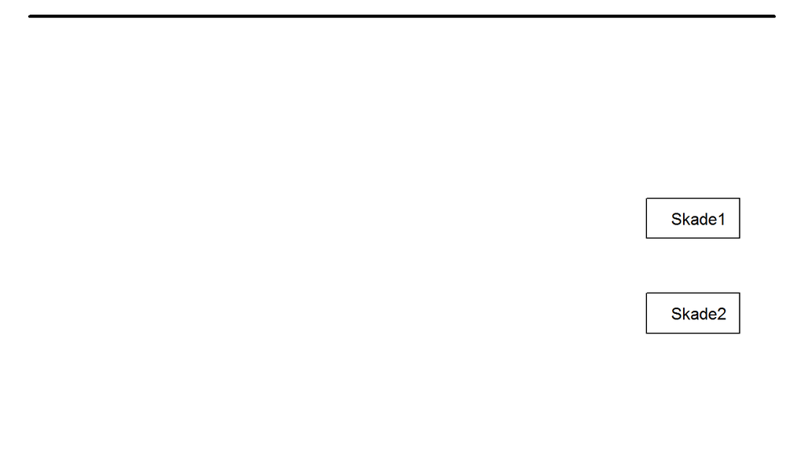

#### Risiko er også vigtigt

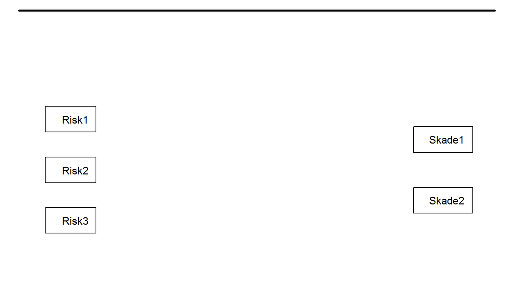

#### Forbindelsen mellem risiko og skade

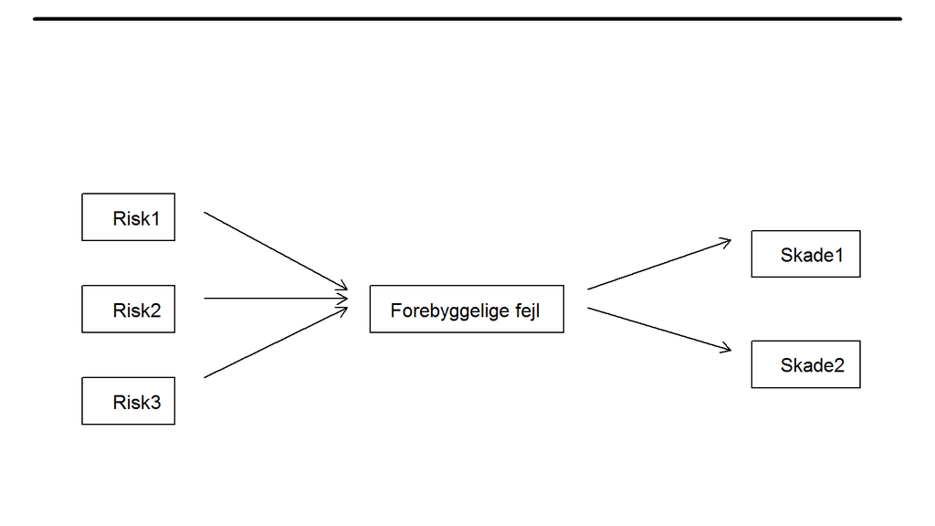

**En kendt ramme**  
- Klassisk epidemiologi

#### Klassisk epidemiologi

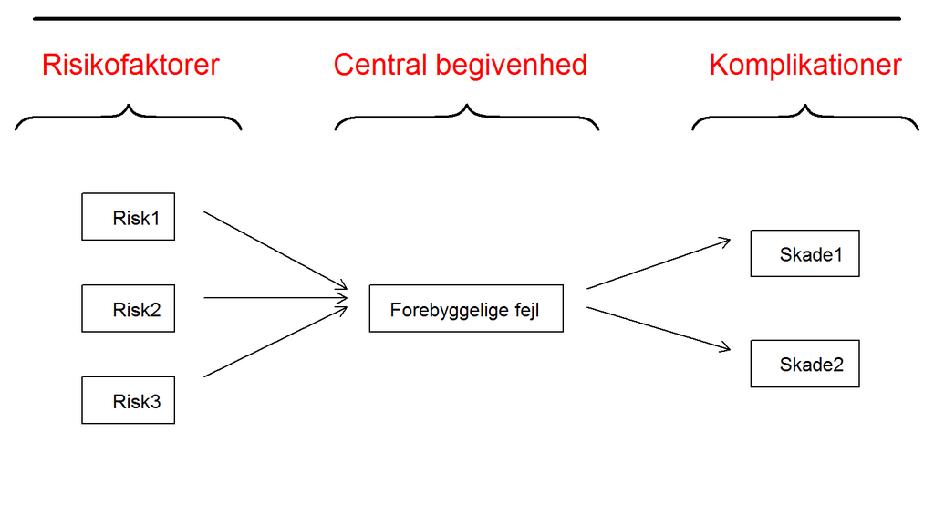

## Hvad er patientsikkerhed?

Definition:  
Patientsikkerhed er læreren om forebyggelige fejl, deres opståen, skadesvirkninger og forebyggelse

**Hvad skal vi måles på?**

**Hvad skal vi måles på?**

I hvor høj grad er vi i stand til at undgå at folk kommer til skade i forbindelse med sundhedsfagligt virke

**Hvad skal sundhedspersoner måles på?**

**Hvad skal sundhedspersoner måles på?**

I hvor høj grad de er i stand til at undgå at at lave forebyggelige fejl

**Hvordan skal vi hjælpe sundhedspersoner?**

**Hvordan skal vi hjælpe sundhedspersoner?**

Vi skal have kendskab til omstændigheder der hhv. øger og mindsker sandsynligheden for forebyggelige fejl og udbrede og implentere dette kendskab

**Hvad er forebyggelige fejl?**

**Hvad er forebyggelige fejl?**

- **Epicentret for patientsikkerhed**
- **Noget som har et vægtigt anker i klinikken**
- **Noget som vi vurderer**

**Hvad er forebyggelige fejl?**

**Dårligt eller uargumenterede afvigelser fra 'standard of practice'**

## Patientsikkerhed?

Definition:  
Patientsikkerhed er læreren om forebyggelige fejl, deres opståen, skadesvirkninger og forebyggelse

**Forebyggelige fejl:**  
**Dårligt eller uargumenterede afvigelser fra 'standard of practice'**

#### Risiko for patientsikkerhed?

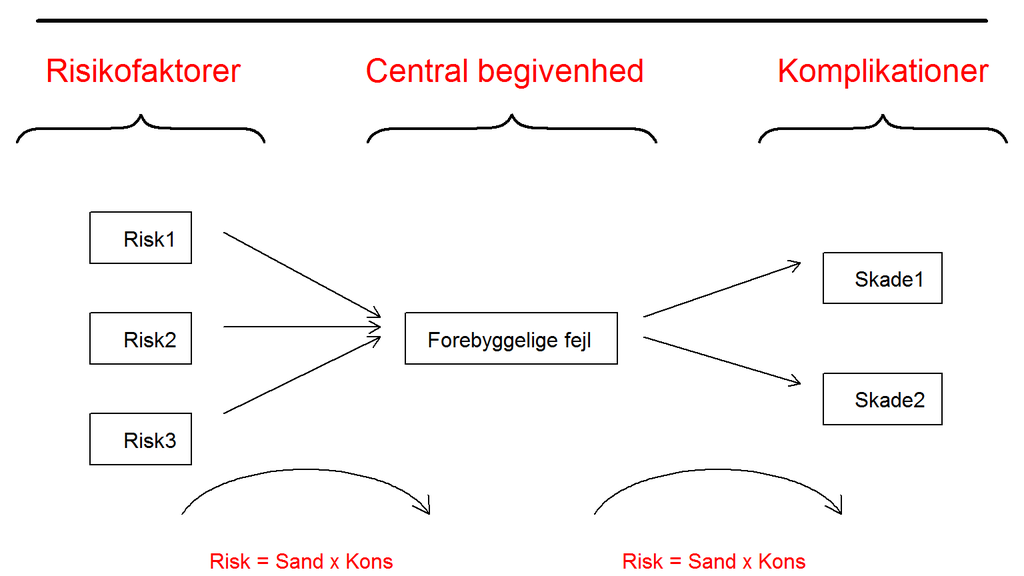

#### Anvendelse

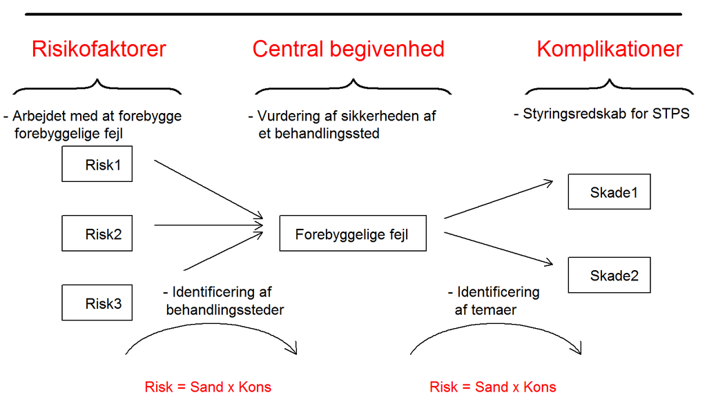

## Indkomne forslag

| Titel.på.forslaget | Saturationsmåling |
| --- | --- |
| Emneord | Behandling, akut behandling, vagtlæge, diagnostik, almen praksis |
| Baggrund for forslaget | Som sagkyndig almen medicin har jeg håndteret flere klagesager, hvor respiratorisk insufficiens er håndteret som hyperventilation med fatale konsekvenser. |
| Tilsyns- eller læringsaktivitet | Øget opmærksomhed på brug af saturationsmåling i almen praksis inklusiv saturationsmåler som en nødvendig ingrediens i lægetaskens indhold. |
| Patientgruppe | Akut vurdering i akutmodtagelse og lægevagtsarbejde |
| Hvem omfattes af tilsynet | Vagtlæger og akutmodtagelser |
| Forventet effekt | Mere sikker vurdering af patienter med åndenød, så mistolkning som hyperventilation mindskes, så behandling med genånding i pose undgås, da det kan være fatalt ved respiratorisk insufficiens. |

## UTH'er

I forbindelse med bedøvning af en patient startes en pumpe med smertestillende medicin på en alt for høj hastighed inden patienten har fået lagt en tube i halsen. Patienten udvikler muskelstivhed udløst af overdosis smertestillende, hvorfor manuel ventilation ikke er muligt. Der konverteres til akut-operationsindledning, dette forløber glat, patienten stabiliseres og resten af operationen forløber planmæssigt.

#### Identifikation af behandlingssteder

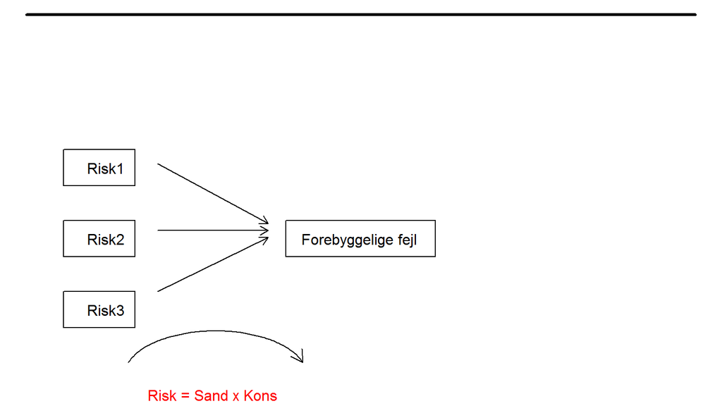

#### Identifikation af behandlingssteder

- Vi anvender egne indsamlede data om forebyggelige fejl fra tilsynsbesøg som outcome  
- Vi anvender egne data som er tilgængelige for alle behandlingsteder som co-variater  
- Vi udvikler modeller som udpeger steder med større sandsynlighed for at score dårligt

#### Kønsfordeling og tilsyn

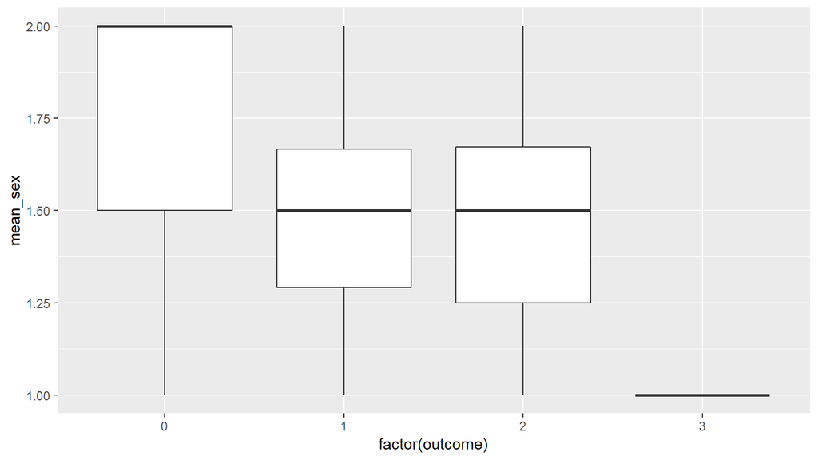

#### Aldersfordeling og tilsyn

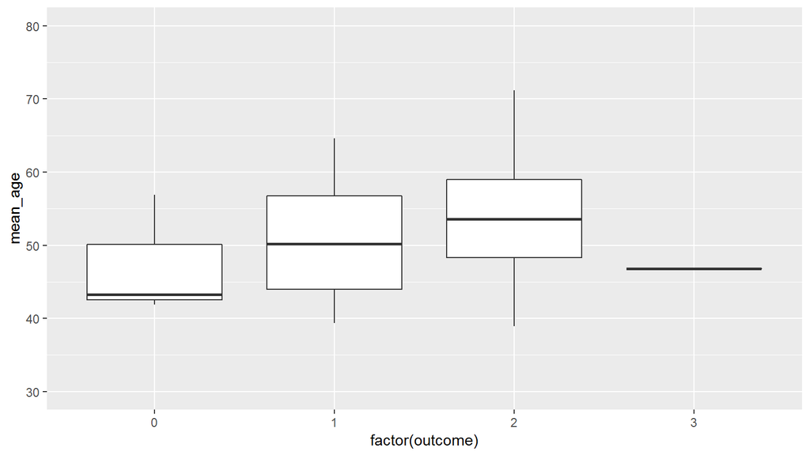

#### Afstand fra universiteter og tilsyn

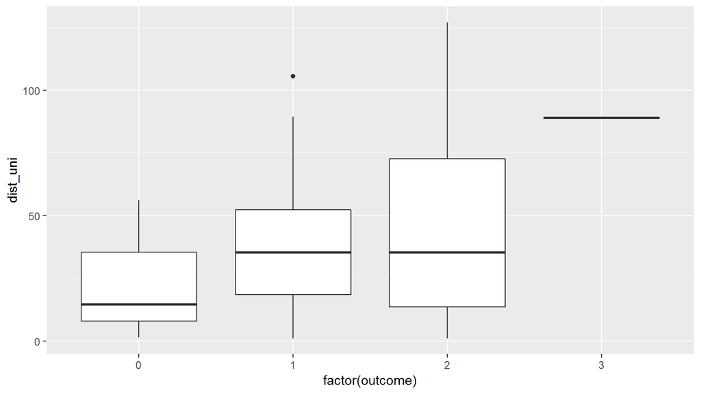

#### Planen er at vi skal forsøge at kigge på mange forskellige parametre

- Antal pt.
- Antal og sammenstæning af ansatte
- Ordinations historik (SPOOP)
- Klagesager (m/u kritik)
- Sanktioner
- Tidligere tilsynsrapporter
- Resultater fra arbejdstilsyns rapporter
- Tid fra udd - Speciale
- Forbrug af kursusdage
- Økonomi
- …

## Resultatet af en forudsigelsesalgoritme

#### Forudsigelse vs. reelt resultat af tilsyn

|  | 0 | 1 | 2 | 3 |
| --- | --- | --- | --- | --- |
| 0 | 0 | 0 | 0 | 0 |
| 1 | 0 | 2 | 4 | 0 |
| 2 | 2 | 2 | 5 | 0 |
| 3 | 0 | 0 | 0 | 0 |

Precision = 47% (95% CI: 21 - 73%)

#### Identifikation af temaer

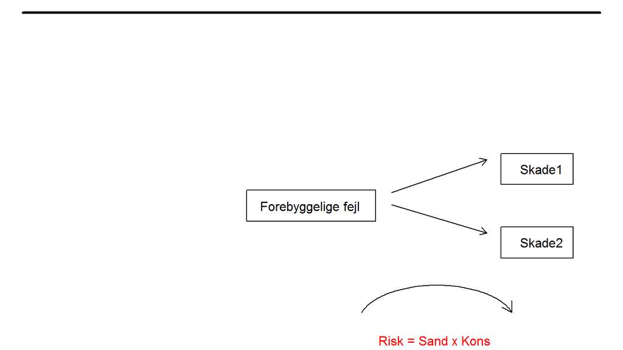

## Kæbenekrose

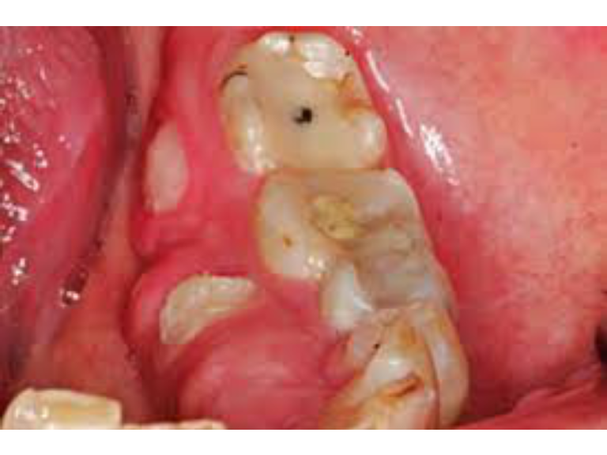

#### Analyser baseret på LPR, SSIK, og LAR

#### Risiko >< fejl >< skade

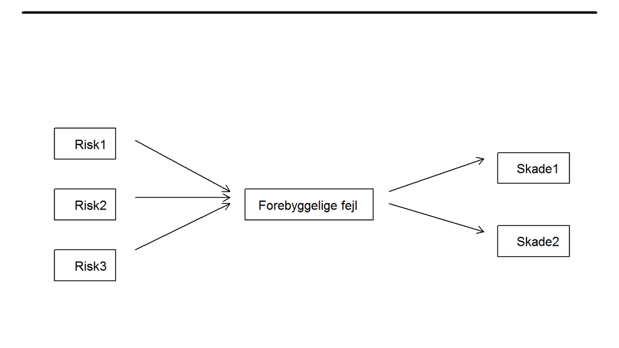

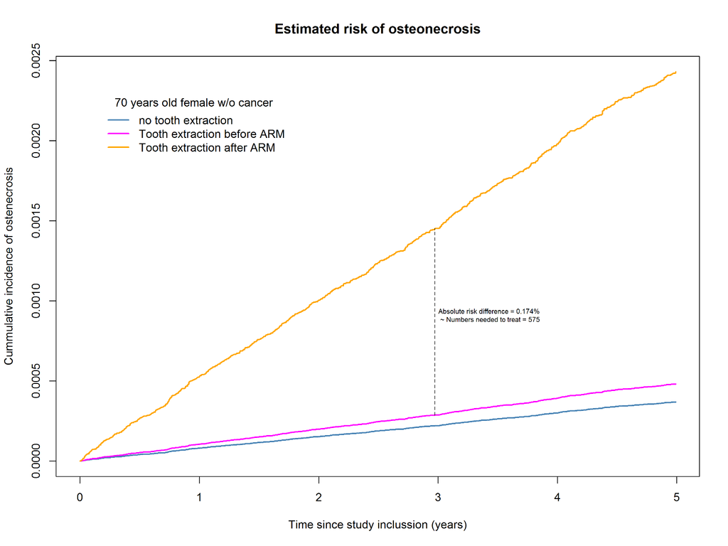

#### Lægemiddelinteraktioner

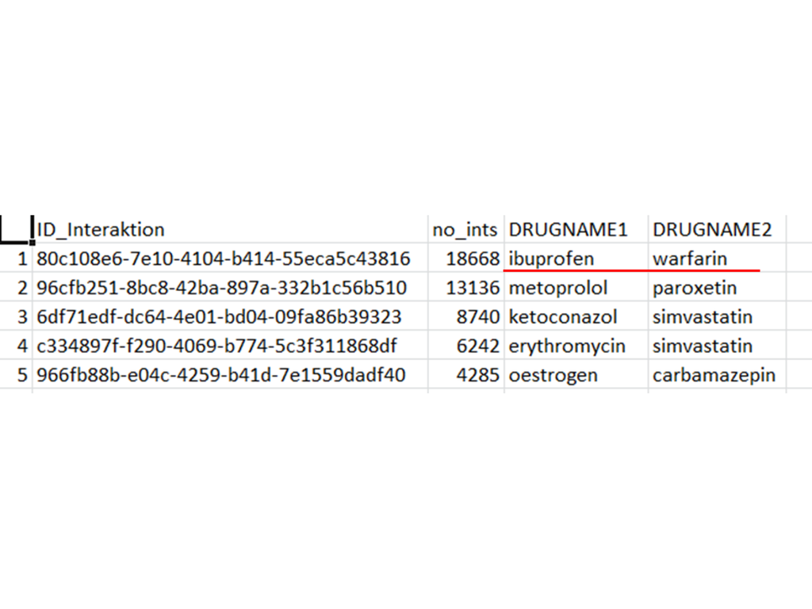

#### Lægemiddelinteraktioner - fortsat

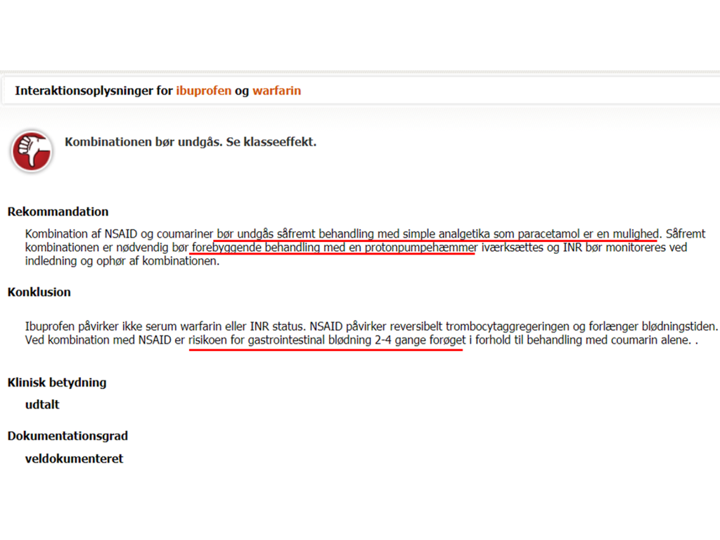

## Løsninger?

1. Hvad forstår vi ved patientsikkerhed?
   - Risiko -> fejl -> skade | risk -> error -> injury
2. Hvad forstår vi ved risiko?
   - Risikoen ved en bestemt type forebyggelig fejl kan beskrives og kvantificeres
   - Antallet af fejl og konsekvenserne på et behandlingssted kan kvantificeres
3. Hvordan identificeres temaer og områder?
   - Der hvor sandsynlighed x konsekvens ved forebyggelige fejl er størst
4. Hvordan identificeres behandlingssteder?
   - Der hvor sandsynligheden for at der begås forebyggelige fejl er størst
5. Hvordan sikrer vi os at vores tiltag gavner?
   - Vi måler på relevante styringsparametre
6. Hvem skal der gås reaktivt tilsyn på? - ?????
7. Hvilke data skal vi bruge og hvordan?